# [Lecture Notebook] Couse Introduction and House Keeping

GE2021 Research Technology, Spring 2025

Author

Chungil CHae

Published

Mon, 3 March 2025

# Learning Objectives

- Instructor & TAs
- Course Introduction
- Course Information
- House Rule

## SHORT VIDEO INTRODUCTION

[video not shown]

# Instructor

- Professor
- Teaching Assitant

## Professor

### Chad (Dr. Chungil Chae)

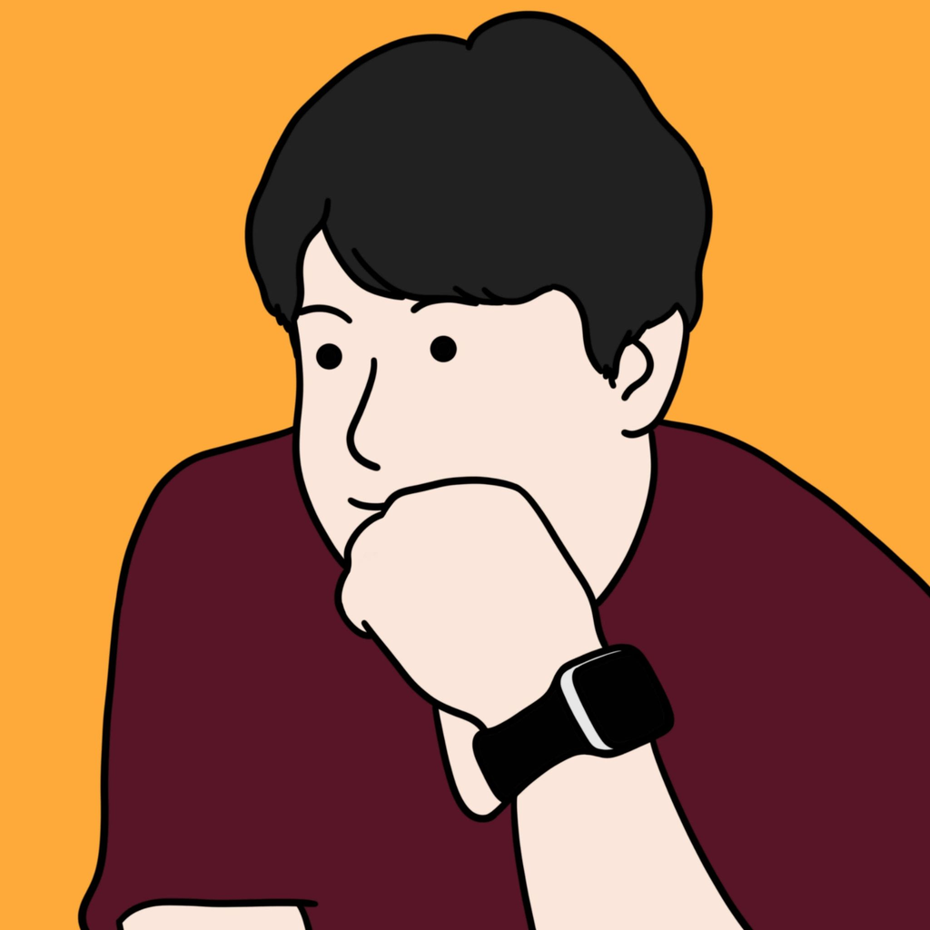

- **Chad** (Chungil Chae)
- CBPM B223 | cchae@kean.edu
- *Assistant Professor* at CBPM, WKU since 2020 Fall
- Call ma Chad, but in formal situation and space, Dr.Chae or Prof.Chae
- Teaching business analytics major courses
  - MGS 3001: Python for Business
  - MGS 3101: Foundation of Business Analytics
  - MGS 3701: Data Mining
  - MGS 4701: Application of Business Analytics

## Teaching Assistant

### Xuwu Zhao

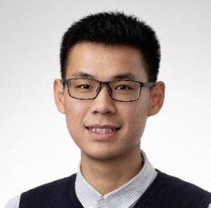

- **Jack** (Xuwu Zhao)
- 1308347@wku.edu.cn
- Sophomore major in *Finance*
- Please feel free to call me Jack. I am truly honored to have the opportunity to serve as your teaching assistant for the GE2021 Research and Technology course this semester.
- Specification
  - awarded the Dean’s Scholarship-First Class
  - Zhejiang Provincial Scholarship for the 2023-2024 academic year
  - interests extend to Management Science and Accounting

# Course Introduction

- GE*2021 RESEARCH AND TECHNOLOGY (3 Credits)
  - Introduction to the research process for students with majors in the College of Business and Public Management. Preparation of a formal research paper. Emphasizes the use of library resources and interdisciplinary approaches to designing, investigating, and reporting research activities. Writing Intensive.

## Chapter 1: The Purpose of Research

1. Describe the purpose of scientific research
2. Describe two theories of knowledge: falsifiability and the scientific revolution
3. Compare and contrast qualitative, quantitative, and mixed methods
4. Explain the importance of ethics and objectivity in research

## Chapter 2: Formulating a Research Question

1. Choose a research topic.
2. Explain how to operationalize research constructs
3. Describe the different types of variables
4. Formulate the various types of hypotheses
5. Create a visualization of a research question

## Chapter 3: Researching and Writing the Literature

1. Describe the purpose of a literature review
2. Learn about online databases as resources
3. Examine different ways of organizing a literature review
4. Discuss how to think critically and analyze studies
5. Identify the correct placement of study hypotheses
6. Compare and contrast a systematic review of the literature and a literature review

## Chapter 4: Quantitative Designs

1. Describe the purpose of exploratory, descriptive, and explanatory studies.
2. Compare and contrast cross-sectional and longitudinal studies.
3. Explain the differences between nomothetic research and idiographic research.
4. Discuss each type of experimental design and its advantages and disadvantages.

## Chapter 5: Measurement Errors, Reliability, Validity

1. Recognize measurement errors and describe how to categorize them.
2. Compare and contrast the interrater reliability, test-retest reliability, and internal consistency reliability.
3. Analyze the different types of validity: face validity, content validity, construct validity, criterion validity, concurrent validity, and predictive validity.

## Chapter 6: Sampling

1. Explain the purpose of sampling.
2. Compare and contrast probability and nonprobability sampling.
3. Describe the types of nonprobability sampling.
4. Summarize the types of probability sampling.
5. Understand sampling error, confidence interval, and saturation.

## Chapter 7: Data Collection for Quantitative Research

1. Familiarize yourself with the details of experimental design.
2. Familiarize yourself with the details of quasi-experimental design.
3. Understand the steps of designing a survey study.
4. Consider additional data collection sources.

## Chapter 8: Secondary Data

1. Describe the benefits of using secondary data.
2. Identify the major sources of secondary data.
3. Explain the drawbacks of using secondary data.

## Chapter 9: Entering and Organizing Quantitative Data

1. Explain the purpose of entering and organizing data logically.
2. Summarize the steps needed to prepare to enter data.
3. Describe how to organize and input variables and their information.

## Chapter 10: Analyzing Quantitative Data

1. Summarize why statistics are used in research methods
2. Conduct univariate analysis
3. Explain the measures of central tendency
4. Define measures of variability and dispersion
5. Describe the various ways to graphically represent data
6. Conduct bivariate analysis

## Chapter 11: Qualitative Designs And Data Collection

1. Plan a qualitative study in a community that is not well known or understood.
2. Understand that qualitative research and quantitative research are not opposed.
3. Do participant observation, write field notes, and manage them in a database.
4. Collect other data, like artifacts, photos, and videos; texts can also be collected.

## Chapter 12: Entering, Coding, and Analyzing Qualitative Data

1. Describe how to enter, clean, and organize qualitative data.
2. Examine and code raw data.
3. Analyze qualitative data.

## Chapter 13: Results and Discussion

1. Write a results section.
2. Describe how to present results in quantitative studies.
3. Explain how to present results in qualitative studies.
4. Prepare visual representations of results.
5. Compose a discussion section.
6. Develop a recommendations section based on methodology or topic.

## Chapter 14: Presenting Your Research

1. Explain how best to present your study to an audience.
2. Discuss how to apply to regional and national conferences.
3. Describe how to get an article published in a peer-reviewed journal.

# Course Information and Syllabus

## Class Information

- GE 2021 W09: Research Technology
- Class time: T, TH 1:00 pm - 2:15 pm
- Class room: CBPM C423

# House Rule

- In class
- Attendence and Absent
- Integration
- AI Useges

## In CLass

- You are expected to read chapter and course material before class
- Based on your class participation, you will get extra score
- Computer and other digital device is allowed **ONLY** students uses it for class related purpose.
- In case instuctor find unauthorized useage of digital device, you will be asked to leave class.

## Attendence and Absent

- **DON”T SENT ME EMAIL or ANY MESSAGE about YOUR ABSENT in ADVANCE**
- More than three times of absents automatically will be marked as F
- Attendence will be managed in student performance application
- When instructor or TA check your attendence and if you are not in class, no matter what reason, your attendence will be marked as absent.
- However, if you have proper and official evidence that WKU allow for absent, bring it to your instructor for revise your absent mark to attendece.

## Integration

- Plagiarism is not tolerated
  - Right after find plagiarism, it will be reported to Office of Vice Chancellor for Academic Affairs directly
  - Student will be kicked out from class immediately
  - Read [Academic Integrity Policy](https://www.wku.edu.cn/sites/wku.sit.site1.drupalagile.com/files/2023-09/WKU-Academic-Integrity-Policy-Students.pdf)

## Generative AI Use in GE 2021

Students in GE 202X are permitted to use AI tools, including, but not limited to, ChatGhT, in this course to generate ideas and brainstorm.

- Think of generative AI as an always-available brainstorming partner. However, you should note that the material generated by these programs may be inaccurate, incomplete, or otherwise problematic. Beware that use may also stifle your independent thinking and creativity.
- Academic work involves developing essential skills such as critical thinking, problem-solving, and effective communication, which cannot be fully developed by relying solely on Artificial Intelligence (AI).
- Your independent research, reading, writing, and discussions with peers and instructors are crucial components of academic work that bring unique value and should not be overlooked or replaced by technology.
- Students should never submit Al-generated work as their original work, as this would constitute a plagiarism violation as defined by the University Academic Integrity Policy and subject to appropriate sanctions.
- The inclusion of Al generated material must always be cited appropriately, like any other reference material.
- Using an Al tool to generate content without proper attribution qualifies as academic dishonesty. Additionally, be aware that information derived from these tools is often incomplete or inaccurate. [How to cite ChatGPT - American Psychological Association](https://apastyle.apa.org/blog/how-to-cite-chatgpt)
- Any assignment found to have been plagiarized or to have used unauthorized Al tools may receive a zero and/or be reported. This underscores the serious consequences of misusing Al tools and the importance of using them responsibly.
- Any use of generative Al-programs such as ChatGPT, GPT 4, DALL-E, Vertex, and many others to come—is subject to the same citation rules as ideas, text, speech, or imagery derived from human authors.
- Any student who is unsure of expectations regarding generative Al tools is encouraged to ask their instructor for clarification.
- This course only accepts 0-10% AI-generated writing in any assignment submission. Any student who submits an assignment with more than 10% AI-generated writing will be asked to revise the work. Failure to make the necessary revisions will result in a no grade failure on those assignments.